# Transported Hessian Adaptive-Threshold Calibration

# Purpose

The transported graph Hessian creates a row by comparing a source directional difference at $u$ with a transported directional difference at $u'$. For a candidate set at the target fiber, let

$$s_{(1)} \le s_{(2)} \le \cdots \le s_{(J)}$$

be the ordered match scores. Adaptive thresholding asks whether the best match is locally good and locally separated enough to trust:

$$m=s_{(2)}-s_{(1)}.$$

The previous report showed the main danger: adaptive rules can reduce polynomial residuals by dropping too many rows. This calibration report therefore treats row retention as a constraint, not as a secondary detail. The main question is:

$$\text{minimize } R_{\mathrm{linear}}
=
\frac{\|AP_{\mathrm{linear}}\|_F}{\|P_{\mathrm{linear}}\|_F}
\quad
\text{subject to}
\quad
\rho_{\mathrm{row}}\ge 0.50
\text{ and nondegeneracy}.$$

**Build:** 2026-05-18 20:55:37 EDT  
**Mode:** full  
**Backends:** `cmdscale`  
**Local grip requested:** TRUE  
**True edge-KK available:** TRUE  
**Edge-KK function:** `grip.optimize.edge.kk.layout`  
**Policies tested:** 42

# Retention-Residual Frontier

Each point is one threshold setting on one graph. The vertical dashed line is the minimum retention constraint $\rho_{\mathrm{row}}\ge 0.50$. Points to the left of the line are informative as diagnostics, but they are not acceptable default candidates because the operator may have been hollowed out.

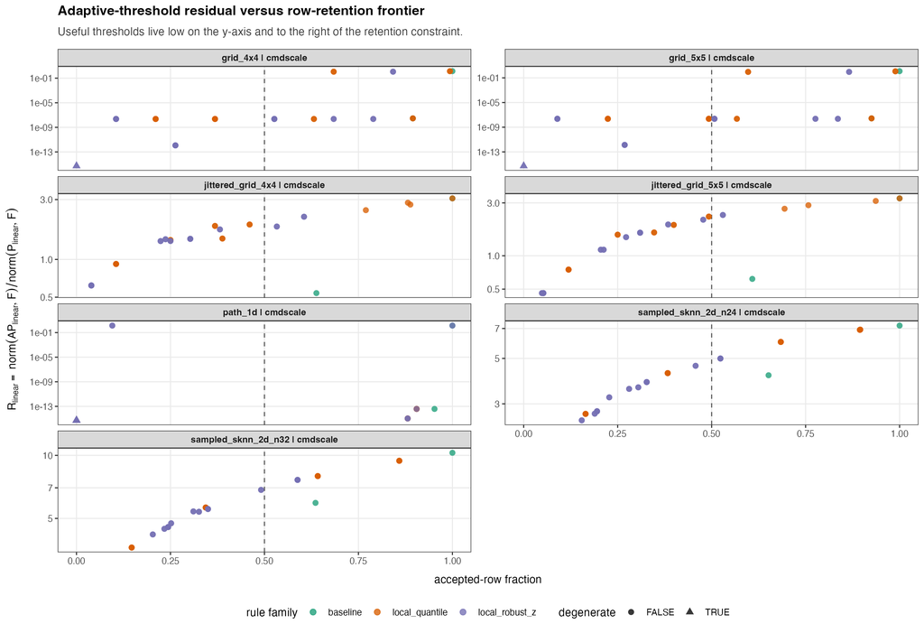

The frontier is the main calibration view. A threshold family is promising only when it improves linear residuals while staying to the right of the retention line. Points with low residual and very low retention are not wins; they are operator-degeneracy warnings.

# Best Feasible Settings

The next figure shows the best feasible setting for each graph/backend pair under the $0.50$ row-retention constraint. The baseline fixed angle/length rule is included, so an adaptive rule must beat a conservative fixed gate while retaining enough rows.

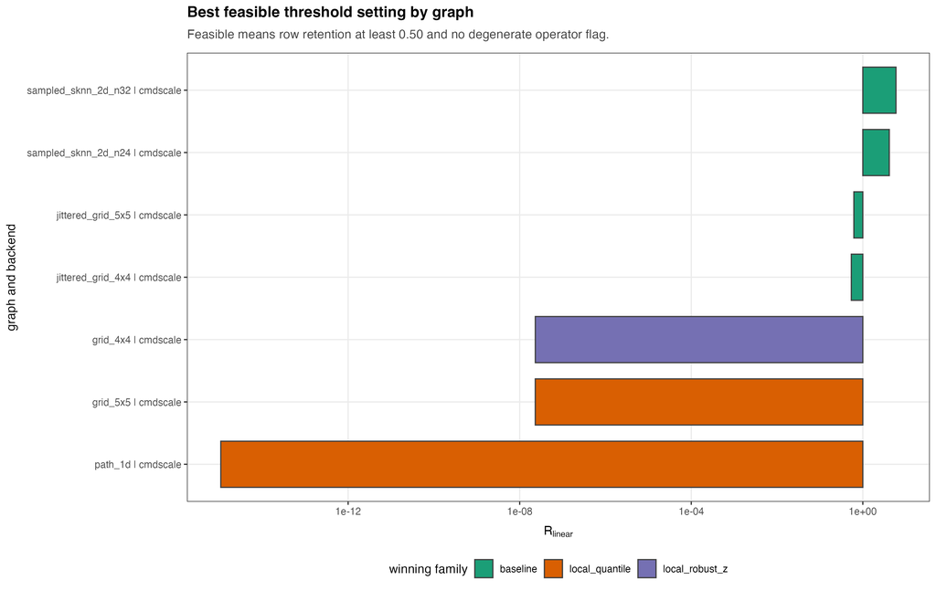

This view answers the practical default question. If the same adaptive family wins repeatedly across graph types, it is a plausible default. If the fixed baseline keeps winning, adaptive gates should remain diagnostic or case-specific until better calibration is available.

# Quantile-Gate Heatmap

The local quantile rule accepts rows when

$$q_s=\widehat F_s(s_{(1)})\le q_{\max},
\qquad
q_m=\widehat F_{\Delta s}(m)\ge q_{\min}.$$

The heatmap reports the best feasible linear residual at each $(q_{\max},q_{\min})$, minimizing over the optional entropy-fraction gate. Blank cells did not meet the row-retention constraint.

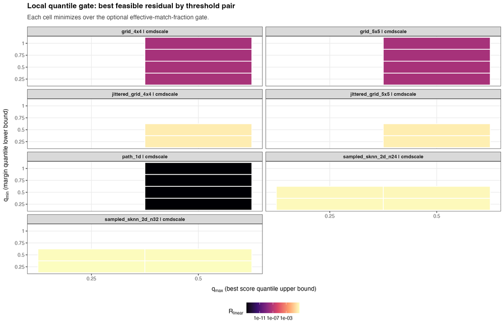

The quantile rule is intentionally local-degree aware, but the heatmap makes its danger visible: as $q_{\min}$ becomes too strict, many graphs lose too many rows and disappear from the feasible set.

# Robust-$z$ Gate Heatmap

The robust-$z$ rule accepts rows when

$$z_s =
\frac{\operatorname{median}(s)-s_{(1)}}{\operatorname{scale}(s)}
\ge z_{s,\min},
\qquad
z_m =
\frac{m-\operatorname{median}(\Delta s)}{\operatorname{scale}(\Delta
s)}
\ge z_{m,\min}.$$

The heatmap reports the best feasible residual at each $(z_{s,\min},z_{m,\min})$, again minimizing over the optional entropy-fraction gate.

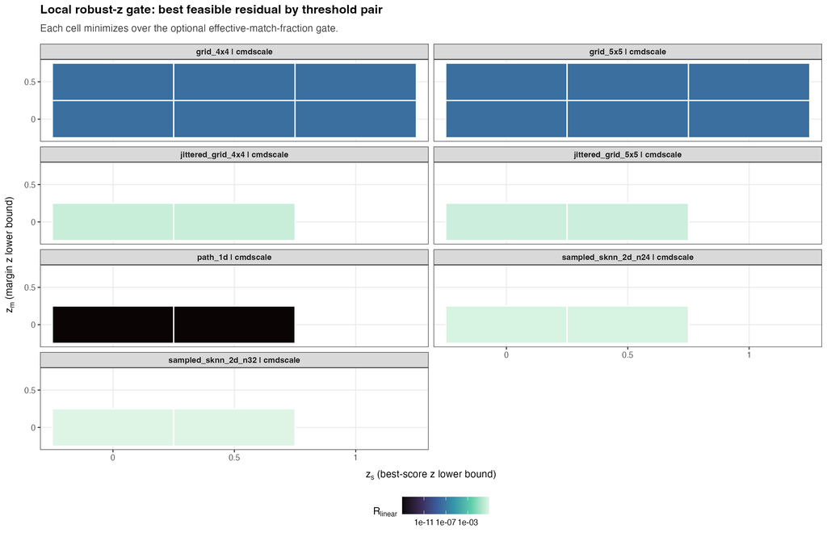

The robust-$z$ rule is less tied to the discreteness of empirical quantiles, but it still needs calibration: large $z$-thresholds can reject exactly the path and boundary comparisons needed to keep the operator meaningful.

# Degeneracy And Drop Mechanisms

Degeneracy is not a secondary warning; it is the failure mode that this report is designed to expose. A very low residual with very low row retention means the operator stopped testing the polynomial probe.

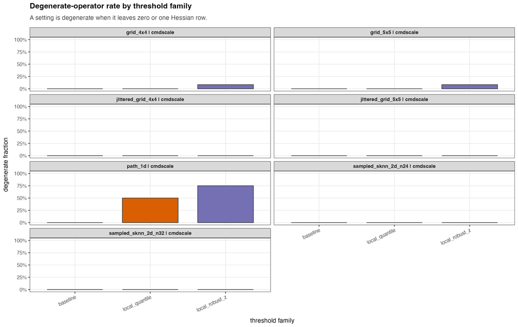

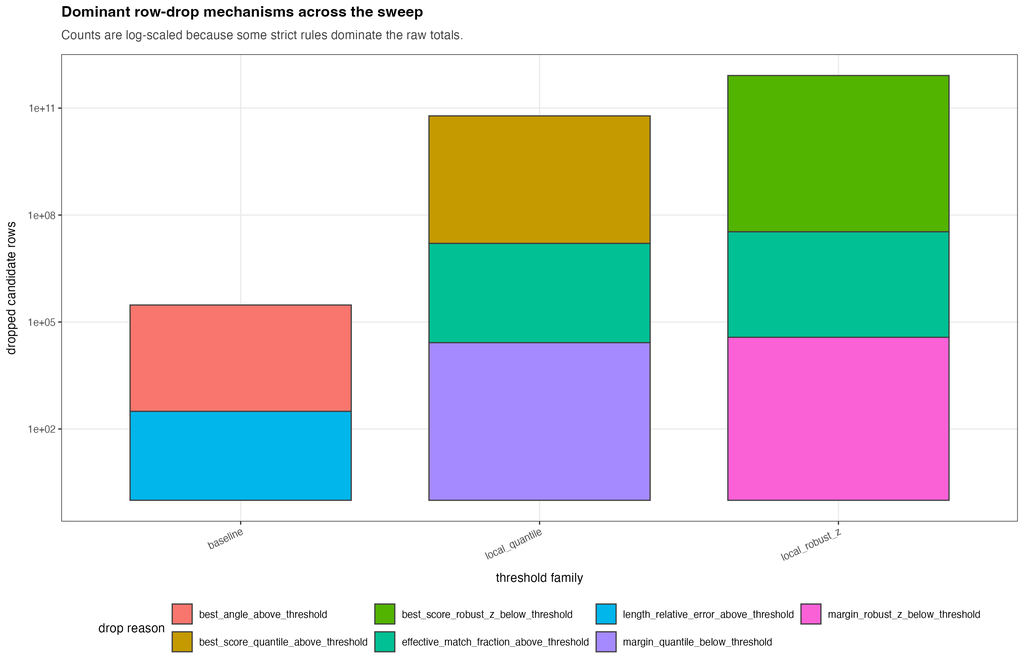

These figures distinguish a useful confidence rule from a destructive thinning rule. A good rule should mostly remove ambiguous local matches while keeping enough rows to maintain a low-dimensional null space.

# Results Summary

Median behavior by threshold family.

| rule.family | row.retention | residual.linear.mean | residual.overall | degenerate |
| --- | --- | --- | --- | --- |
| baseline | 0.9762 | 1.3859 | 1.5425 | 0 |
| local_quantile | 0.4299 | 1.3935 | 1.4161 | 0 |
| local_robust_z | 0.2632 | 1.1339 | 1.0518 | 0 |

Best feasible policy by graph/backend pair.

|  | case.id | local.embedding.method | rule.family | transport.filter | row.retention | residual.linear.mean | nullity.estimate | mean.effective.match.fraction |
| --- | --- | --- | --- | --- | --- | --- | --- | --- |
| 161 | grid_4x4 | cmdscale | local_robust_z | robust_z_zs0.0_zm0.5_noef | 0.5263 | 0.0000 | 1 | 0.3000 |
| 111 | grid_5x5 | cmdscale | local_quantile | quantile_qs0.50_qm0.75_ef0.50 | 0.5672 | 0.0000 | 1 | 0.3180 |
| 10 | jittered_grid_4x4 | cmdscale | baseline | baseline_fixed_geometric | 0.6382 | 0.5390 | 1 | 0.3521 |
| 13 | jittered_grid_5x5 | cmdscale | baseline | baseline_fixed_geometric | 0.6082 | 0.6183 | 1 | 0.3100 |
| 82 | path_1d | cmdscale | local_quantile | quantile_qs0.50_qm0.25_ef0.50 | 0.8810 | 0.0000 | 2 | 0.5000 |
| 11 | sampled_sknn_2d_n24 | cmdscale | baseline | baseline_fixed_geometric | 0.6514 | 4.1374 | 1 | 0.1666 |
| 14 | sampled_sknn_2d_n32 | cmdscale | baseline | baseline_fixed_geometric | 0.6358 | 5.9318 | 1 | 0.1369 |

The calibration experiment should be read conservatively. The best threshold is not the one with the smallest residual in isolation; it is the one with the smallest residual among policies that retain enough rows and avoid degeneracy. This report therefore turns adaptive thresholding from an attractive idea into a measurable tradeoff.

## What We Learned

Best feasible policy counts by graph/backend pair: `baseline`: 4; `local_quantile`: 2; `local_robust_z`: 1.

The practical conclusion is that adaptive gates are useful calibration tools, but they are not yet a safe universal default. The fixed angle/length gate remains the conservative baseline whenever an adaptive rule improves residuals mainly by moving leftward on the retention frontier.

The expected outcome is not necessarily a single universal default. It may be that fixed angle/length gates are safer on irregular or sampled graphs, while adaptive gates are useful on clean path/grid references. If the frontier shows that pattern, the next implementation step should expose adaptive gates as diagnostics or case-specific policies rather than making them the default.

# Appendix

## Run Metadata

```
## List of 9
##  $ mode             : chr "full"
##  $ generated.at     : chr "2026-05-18 20:55:37 EDT"
##  $ use.local.grip   : logi TRUE
##  $ grip.available   : logi TRUE
##  $ edge.kk.available: logi TRUE
##  $ edge.kk.function : chr "grip.optimize.edge.kk.layout"
##  $ methods          : chr "cmdscale"
##  $ min.row.retention: num [1:3] 0.25 0.5 0.75
##  $ gflow.repo       : chr "/Users/pgajer/current_projects/gflow"
```

## Policy Grid

| transport.filter | filter.label | rule.family | description | max.match.angle | max.length.relative.error | match.threshold.rule | match.score.quantile | match.margin.quantile | min.best.score.z | min.margin.z | max.effective.match.fraction |
| --- | --- | --- | --- | --- | --- | --- | --- | --- | --- | --- | --- |
| baseline_none | No filter | baseline | All candidate soft-transport rows are retained. | NA | NA | fixed | NA | NA | NA | NA | NA |
| baseline_fixed_geometric | Fixed angle/length | baseline | Fixed geometric gate: best angle at most pi/3 and relative length error at most 0.50. | 1.0472 | 0.5 | fixed | NA | NA | NA | NA | NA |
| quantile_qs0.25_qm0.25_noef | Quantile qs=0.25 qm=0.25 noef | local_quantile | Adaptive local quantile gate on best score and best-vs-second margin. | NA | NA | local.quantile | 0.25 | 0.25 | NA | NA | NA |
| quantile_qs0.50_qm0.25_noef | Quantile qs=0.50 qm=0.25 noef | local_quantile | Adaptive local quantile gate on best score and best-vs-second margin. | NA | NA | local.quantile | 0.50 | 0.25 | NA | NA | NA |
| quantile_qs0.25_qm0.50_noef | Quantile qs=0.25 qm=0.50 noef | local_quantile | Adaptive local quantile gate on best score and best-vs-second margin. | NA | NA | local.quantile | 0.25 | 0.50 | NA | NA | NA |
| quantile_qs0.50_qm0.50_noef | Quantile qs=0.50 qm=0.50 noef | local_quantile | Adaptive local quantile gate on best score and best-vs-second margin. | NA | NA | local.quantile | 0.50 | 0.50 | NA | NA | NA |
| quantile_qs0.25_qm0.75_noef | Quantile qs=0.25 qm=0.75 noef | local_quantile | Adaptive local quantile gate on best score and best-vs-second margin. | NA | NA | local.quantile | 0.25 | 0.75 | NA | NA | NA |
| quantile_qs0.50_qm0.75_noef | Quantile qs=0.50 qm=0.75 noef | local_quantile | Adaptive local quantile gate on best score and best-vs-second margin. | NA | NA | local.quantile | 0.50 | 0.75 | NA | NA | NA |
| quantile_qs0.25_qm1.00_noef | Quantile qs=0.25 qm=1.00 noef | local_quantile | Adaptive local quantile gate on best score and best-vs-second margin. | NA | NA | local.quantile | 0.25 | 1.00 | NA | NA | NA |
| quantile_qs0.50_qm1.00_noef | Quantile qs=0.50 qm=1.00 noef | local_quantile | Adaptive local quantile gate on best score and best-vs-second margin. | NA | NA | local.quantile | 0.50 | 1.00 | NA | NA | NA |
| quantile_qs0.25_qm0.25_ef0.50 | Quantile qs=0.25 qm=0.25 ef0.50 | local_quantile | Adaptive local quantile gate on best score and best-vs-second margin. | NA | NA | local.quantile | 0.25 | 0.25 | NA | NA | 0.5 |
| quantile_qs0.50_qm0.25_ef0.50 | Quantile qs=0.50 qm=0.25 ef0.50 | local_quantile | Adaptive local quantile gate on best score and best-vs-second margin. | NA | NA | local.quantile | 0.50 | 0.25 | NA | NA | 0.5 |
| quantile_qs0.25_qm0.50_ef0.50 | Quantile qs=0.25 qm=0.50 ef0.50 | local_quantile | Adaptive local quantile gate on best score and best-vs-second margin. | NA | NA | local.quantile | 0.25 | 0.50 | NA | NA | 0.5 |
| quantile_qs0.50_qm0.50_ef0.50 | Quantile qs=0.50 qm=0.50 ef0.50 | local_quantile | Adaptive local quantile gate on best score and best-vs-second margin. | NA | NA | local.quantile | 0.50 | 0.50 | NA | NA | 0.5 |
| quantile_qs0.25_qm0.75_ef0.50 | Quantile qs=0.25 qm=0.75 ef0.50 | local_quantile | Adaptive local quantile gate on best score and best-vs-second margin. | NA | NA | local.quantile | 0.25 | 0.75 | NA | NA | 0.5 |
| quantile_qs0.50_qm0.75_ef0.50 | Quantile qs=0.50 qm=0.75 ef0.50 | local_quantile | Adaptive local quantile gate on best score and best-vs-second margin. | NA | NA | local.quantile | 0.50 | 0.75 | NA | NA | 0.5 |
| quantile_qs0.25_qm1.00_ef0.50 | Quantile qs=0.25 qm=1.00 ef0.50 | local_quantile | Adaptive local quantile gate on best score and best-vs-second margin. | NA | NA | local.quantile | 0.25 | 1.00 | NA | NA | 0.5 |
| quantile_qs0.50_qm1.00_ef0.50 | Quantile qs=0.50 qm=1.00 ef0.50 | local_quantile | Adaptive local quantile gate on best score and best-vs-second margin. | NA | NA | local.quantile | 0.50 | 1.00 | NA | NA | 0.5 |
| robust_z_zs0.0_zm0.0_noef | Robust-z zs=0.0 zm=0.0 noef | local_robust_z | Adaptive local robust-z gate on best score and best-vs-second margin. | NA | NA | local.robust.z | NA | NA | 0.0 | 0.0 | NA |
| robust_z_zs0.5_zm0.0_noef | Robust-z zs=0.5 zm=0.0 noef | local_robust_z | Adaptive local robust-z gate on best score and best-vs-second margin. | NA | NA | local.robust.z | NA | NA | 0.5 | 0.0 | NA |
| robust_z_zs1.0_zm0.0_noef | Robust-z zs=1.0 zm=0.0 noef | local_robust_z | Adaptive local robust-z gate on best score and best-vs-second margin. | NA | NA | local.robust.z | NA | NA | 1.0 | 0.0 | NA |
| robust_z_zs1.5_zm0.0_noef | Robust-z zs=1.5 zm=0.0 noef | local_robust_z | Adaptive local robust-z gate on best score and best-vs-second margin. | NA | NA | local.robust.z | NA | NA | 1.5 | 0.0 | NA |
| robust_z_zs0.0_zm0.5_noef | Robust-z zs=0.0 zm=0.5 noef | local_robust_z | Adaptive local robust-z gate on best score and best-vs-second margin. | NA | NA | local.robust.z | NA | NA | 0.0 | 0.5 | NA |
| robust_z_zs0.5_zm0.5_noef | Robust-z zs=0.5 zm=0.5 noef | local_robust_z | Adaptive local robust-z gate on best score and best-vs-second margin. | NA | NA | local.robust.z | NA | NA | 0.5 | 0.5 | NA |
| robust_z_zs1.0_zm0.5_noef | Robust-z zs=1.0 zm=0.5 noef | local_robust_z | Adaptive local robust-z gate on best score and best-vs-second margin. | NA | NA | local.robust.z | NA | NA | 1.0 | 0.5 | NA |
| robust_z_zs1.5_zm0.5_noef | Robust-z zs=1.5 zm=0.5 noef | local_robust_z | Adaptive local robust-z gate on best score and best-vs-second margin. | NA | NA | local.robust.z | NA | NA | 1.5 | 0.5 | NA |
| robust_z_zs0.0_zm1.0_noef | Robust-z zs=0.0 zm=1.0 noef | local_robust_z | Adaptive local robust-z gate on best score and best-vs-second margin. | NA | NA | local.robust.z | NA | NA | 0.0 | 1.0 | NA |
| robust_z_zs0.5_zm1.0_noef | Robust-z zs=0.5 zm=1.0 noef | local_robust_z | Adaptive local robust-z gate on best score and best-vs-second margin. | NA | NA | local.robust.z | NA | NA | 0.5 | 1.0 | NA |
| robust_z_zs1.0_zm1.0_noef | Robust-z zs=1.0 zm=1.0 noef | local_robust_z | Adaptive local robust-z gate on best score and best-vs-second margin. | NA | NA | local.robust.z | NA | NA | 1.0 | 1.0 | NA |
| robust_z_zs1.5_zm1.0_noef | Robust-z zs=1.5 zm=1.0 noef | local_robust_z | Adaptive local robust-z gate on best score and best-vs-second margin. | NA | NA | local.robust.z | NA | NA | 1.5 | 1.0 | NA |
| robust_z_zs0.0_zm0.0_ef0.50 | Robust-z zs=0.0 zm=0.0 ef0.50 | local_robust_z | Adaptive local robust-z gate on best score and best-vs-second margin. | NA | NA | local.robust.z | NA | NA | 0.0 | 0.0 | 0.5 |
| robust_z_zs0.5_zm0.0_ef0.50 | Robust-z zs=0.5 zm=0.0 ef0.50 | local_robust_z | Adaptive local robust-z gate on best score and best-vs-second margin. | NA | NA | local.robust.z | NA | NA | 0.5 | 0.0 | 0.5 |
| robust_z_zs1.0_zm0.0_ef0.50 | Robust-z zs=1.0 zm=0.0 ef0.50 | local_robust_z | Adaptive local robust-z gate on best score and best-vs-second margin. | NA | NA | local.robust.z | NA | NA | 1.0 | 0.0 | 0.5 |
| robust_z_zs1.5_zm0.0_ef0.50 | Robust-z zs=1.5 zm=0.0 ef0.50 | local_robust_z | Adaptive local robust-z gate on best score and best-vs-second margin. | NA | NA | local.robust.z | NA | NA | 1.5 | 0.0 | 0.5 |
| robust_z_zs0.0_zm0.5_ef0.50 | Robust-z zs=0.0 zm=0.5 ef0.50 | local_robust_z | Adaptive local robust-z gate on best score and best-vs-second margin. | NA | NA | local.robust.z | NA | NA | 0.0 | 0.5 | 0.5 |
| robust_z_zs0.5_zm0.5_ef0.50 | Robust-z zs=0.5 zm=0.5 ef0.50 | local_robust_z | Adaptive local robust-z gate on best score and best-vs-second margin. | NA | NA | local.robust.z | NA | NA | 0.5 | 0.5 | 0.5 |
| robust_z_zs1.0_zm0.5_ef0.50 | Robust-z zs=1.0 zm=0.5 ef0.50 | local_robust_z | Adaptive local robust-z gate on best score and best-vs-second margin. | NA | NA | local.robust.z | NA | NA | 1.0 | 0.5 | 0.5 |
| robust_z_zs1.5_zm0.5_ef0.50 | Robust-z zs=1.5 zm=0.5 ef0.50 | local_robust_z | Adaptive local robust-z gate on best score and best-vs-second margin. | NA | NA | local.robust.z | NA | NA | 1.5 | 0.5 | 0.5 |
| robust_z_zs0.0_zm1.0_ef0.50 | Robust-z zs=0.0 zm=1.0 ef0.50 | local_robust_z | Adaptive local robust-z gate on best score and best-vs-second margin. | NA | NA | local.robust.z | NA | NA | 0.0 | 1.0 | 0.5 |
| robust_z_zs0.5_zm1.0_ef0.50 | Robust-z zs=0.5 zm=1.0 ef0.50 | local_robust_z | Adaptive local robust-z gate on best score and best-vs-second margin. | NA | NA | local.robust.z | NA | NA | 0.5 | 1.0 | 0.5 |
| robust_z_zs1.0_zm1.0_ef0.50 | Robust-z zs=1.0 zm=1.0 ef0.50 | local_robust_z | Adaptive local robust-z gate on best score and best-vs-second margin. | NA | NA | local.robust.z | NA | NA | 1.0 | 1.0 | 0.5 |
| robust_z_zs1.5_zm1.0_ef0.50 | Robust-z zs=1.5 zm=1.0 ef0.50 | local_robust_z | Adaptive local robust-z gate on best score and best-vs-second margin. | NA | NA | local.robust.z | NA | NA | 1.5 | 1.0 | 0.5 |

## Summary Table

[output not shown]

[output cut: 264 more lines]

## Reproducibility

Smoke render:

```bash
Rscript dev/graph-trend-filtering/render_transported_hessian_adaptive_threshold_sweep.R
```

Full render:

```bash
GFLOW_ADAPTIVE_THRESHOLD_SWEEP_MODE=full Rscript dev/graph-trend-filtering/render_transported_hessian_adaptive_threshold_sweep.R
```